# 市场观察

2016/11/17

## 一、指数估值

### (一)动态市盈率、市净率

核心指数成分股近18个月的动态市盈率及动态市净率中位数走势如下图所示：

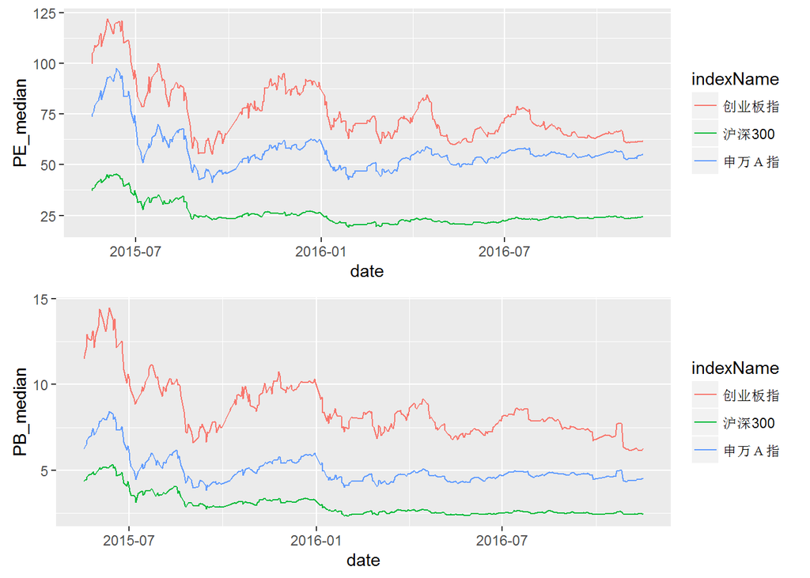

### (二)动态市盈率、市净率百分位

核心指数近18个月的动态市盈率百分位及动态市净率百分位走势如下图所示：

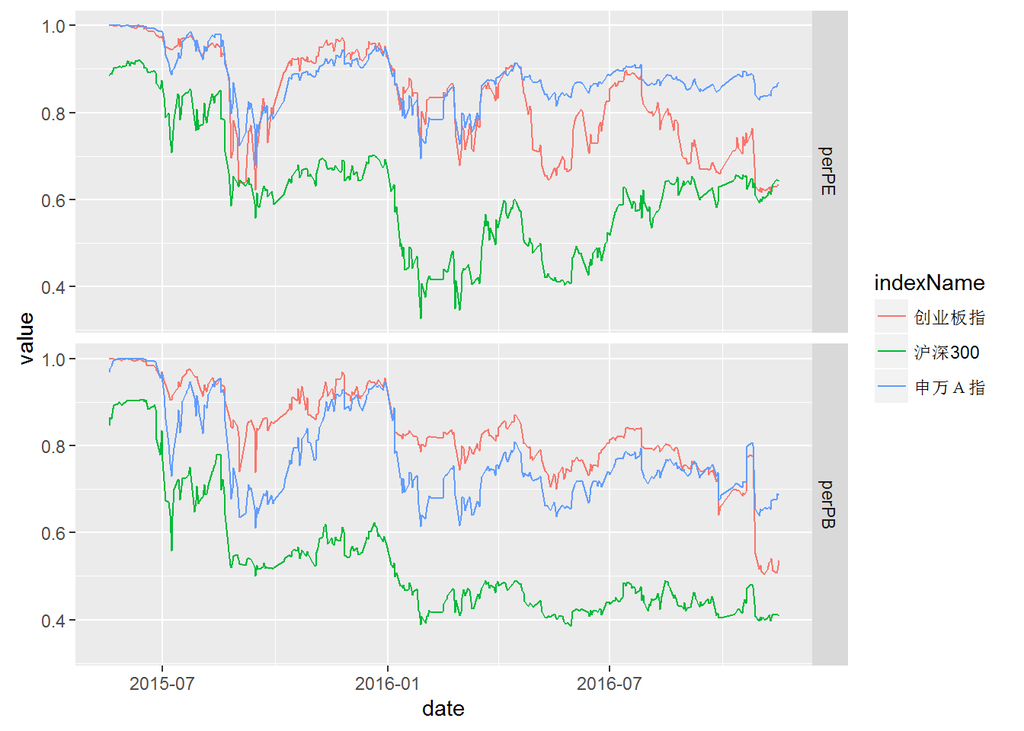

### (三)指数估值概览

纳入观察的18只指数最新的估值情况如下表：

| 日期 | 指数代码 | 指数简称 | 动态市盈率 | 市盈率百分位 | 动态市净率 | 市净率百分位 |
| --- | --- | --- | --- | --- | --- | --- |
| 2016-11-16 | EI000805 | A股资源 | 67.2 | 99.4% | 2.5 | 58.9% |
| 2016-11-16 | EI000979 | 大宗商品 | 54.7 | 98.2% | 2.6 | 51.4% |
| 2016-11-16 | EI801003 | 申万Ａ指 | 55.3 | 87.1% | 4.5 | 68.7% |
| 2016-11-16 | EI000808 | 医药生物 | 45.4 | 85.3% | 4.7 | 27.7% |
| 2016-11-16 | EI000933 | 中证医药 | 43.7 | 84.6% | 4.0 | 8.2% |
| 2016-11-16 | EI399005 | 中小板指P | 44.9 | 79.0% | 4.9 | 52.0% |
| 2016-11-16 | EI399959 | 军工指数 | 92.2 | 77.7% | 5.2 | 63.7% |
| 2016-11-16 | EI399330 | 深证100 | 34.9 | 76.0% | 4.0 | 61.1% |
| 2016-11-16 | EI000819 | 有色金属 | 53.6 | 75.5% | 3.7 | 71.5% |
| 2016-11-16 | EI000934 | 中证金融 | 20.3 | 69.5% | 2.1 | 36.4% |
| 2016-11-16 | EI000300 | 沪深300 | 24.4 | 64.6% | 2.4 | 40.8% |
| 2016-11-16 | EI399006 | 创业板指 | 61.7 | 63.4% | 6.3 | 53.6% |
| 2016-11-16 | EI000998 | 中证TMT | 49.8 | 63.0% | 4.7 | 44.4% |
| 2016-11-16 | EI000905 | 中证500 | 39.4 | 62.9% | 3.3 | 47.0% |
| 2016-11-16 | EI000827 | 中证环保 | 39.6 | 54.5% | 3.2 | 32.7% |
| 2016-11-16 | EI000016 | 上证50 | 16.5 | 50.9% | 1.6 | 15.8% |
| 2016-11-16 | EI801120 | 申万食品饮料 | 39.3 | 49.7% | 4.8 | 68.9% |
| 2016-11-16 | EI000932 | 中证消费 | 30.5 | 36.0% | 4.0 | 31.9% |

## 二、基差

### (一)基差走势

三大股指期货合约基差走势如下图，其中当月合约和次月合约年化基差百分比波动较大，仅展示合约基差百分比，当季合约和次季合约展示基差年化百分比：

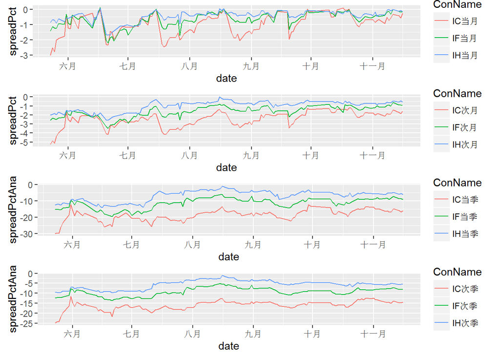

### (二)基差概况

三大股指期货连续合约基差概况如下表，近月合约临近到期日，年化基差百分比数据波动较大：

| 日期 | 合约代码 | 合约收盘价 | 指数收盘价 | 基差 | 基差百分比 | 年化基差百分比 |
| --- | --- | --- | --- | --- | --- | --- |
| 2016-11-16 | IC1611 | 6627.4 | 6644.19 | -16.79 | -0.25% | -58.5% |
| 2016-11-16 | IC1612 | 6538.4 | 6644.19 | -105.79 | -1.59% | -21.2% |
| 2016-11-16 | IC1703 | 6309.8 | 6644.19 | -334.39 | -5.03% | -16.0% |
| 2016-11-16 | IC1706 | 6105.8 | 6644.19 | -538.39 | -8.10% | -14.4% |
| 2016-11-16 | IF1611 | 3423.6 | 3429.59 | -5.99 | -0.17% | -37.5% |
| 2016-11-16 | IF1612 | 3398.2 | 3429.59 | -31.39 | -0.92% | -11.7% |
| 2016-11-16 | IF1703 | 3328.4 | 3429.59 | -101.19 | -2.95% | -9.2% |
| 2016-11-16 | IF1706 | 3272.4 | 3429.59 | -157.19 | -4.58% | -8.0% |
| 2016-11-16 | IH1611 | 2306.2 | 2309.94 | -3.74 | -0.16% | -34.4% |
| 2016-11-16 | IH1612 | 2297.4 | 2309.94 | -12.54 | -0.54% | -6.8% |
| 2016-11-16 | IH1703 | 2263.2 | 2309.94 | -46.74 | -2.02% | -6.2% |
| 2016-11-16 | IH1706 | 2238.6 | 2309.94 | -71.34 | -3.09% | -5.4% |

## 三、套利

### (一)复牌股票套利

近两天复牌股票套利情况如下表：

[1] “无复牌股票套利”

### (二)定增基金跟踪

截止2016-11-17定增基金数据如下表，明细数据参见钱瀚的模板。

| 代码 | 名称 | 到期日期 | 最新净值 | 昨日收盘价 | 折溢价率 | 整体隐含折价率 | 大盘回撤0.1净值回撤 |
| --- | --- | --- | --- | --- | --- | --- | --- |
| 168101.OF | 九泰锐智 | 20200814 | 1.42 | 1.33 | -6.4% | 6.5% | -6.3% |
| 168102.OF | 九泰锐富 | 20210204 | 1.04 | 1.00 | -4.7% | 3.4% | -2.7% |
| 501015.OF | 财通升级 | 20170908 | 1.08 | 1.01 | -5.7% | 10.1% | -5.7% |
| 160518.OF | 博时睿远 | 20171016 | 1.02 | 0.99 | -2.9% | 8.1% | -3.6% |

定增基金近期的净值走势如下图：

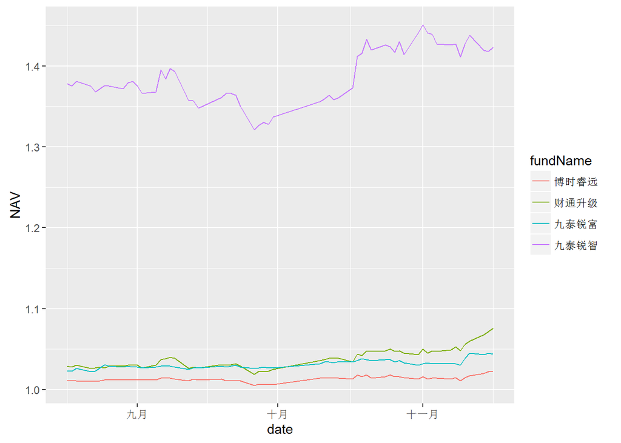

定增基金近期的折溢价率百分比走势如下图：

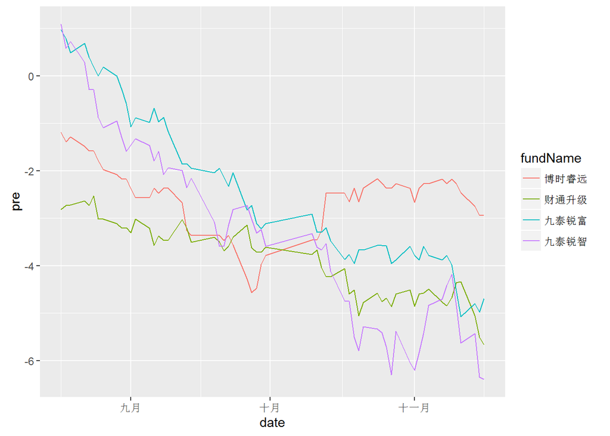

## 四、择时

### (一)大盘均线强弱指数

大盘均线强弱指数在一定程度上可以视为一个反转指标，当大盘均线得分接近8分时，预示市场接近顶部，当大盘均线得分接近0分时，预示市场接近底部。  
大盘均线强弱指数近一年来走势如下图：

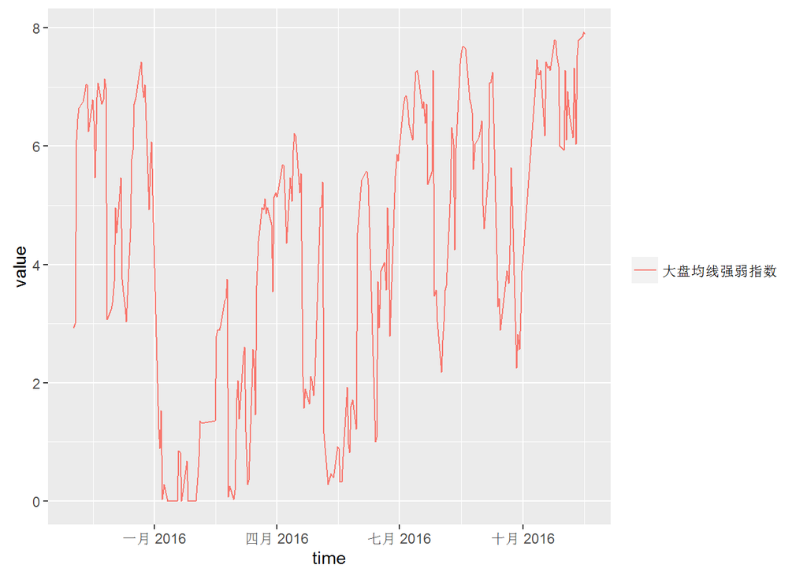

申万一级行业的最新得分见下表：

| 日期 | 指数代码 | 行业 | 最新得分 | 上周得分 |
| --- | --- | --- | --- | --- |
| 2016-11-16 | EI801010 | 农林牧渔 | 8 | 8 |
| 2016-11-16 | EI801020 | 采掘 | 8 | 8 |
| 2016-11-16 | EI801030 | 化工 | 8 | 8 |
| 2016-11-16 | EI801040 | 钢铁 | 8 | 8 |
| 2016-11-16 | EI801050 | 有色金属 | 8 | 8 |
| 2016-11-16 | EI801080 | 电子 | 8 | 8 |
| 2016-11-16 | EI801110 | 家用电器 | 8 | 8 |
| 2016-11-16 | EI801120 | 食品饮料 | 8 | 8 |
| 2016-11-16 | EI801130 | 纺织服装 | 8 | 8 |
| 2016-11-16 | EI801140 | 轻工制造 | 8 | 8 |
| 2016-11-16 | EI801150 | 医药生物 | 8 | 8 |
| 2016-11-16 | EI801160 | 公用事业 | 8 | 8 |
| 2016-11-16 | EI801170 | 交通运输 | 8 | 7 |
| 2016-11-16 | EI801180 | 房地产 | 8 | 8 |
| 2016-11-16 | EI801200 | 商业贸易 | 8 | 8 |
| 2016-11-16 | EI801210 | 休闲服务 | 8 | 8 |
| 2016-11-16 | EI801230 | 综合 | 8 | 7 |
| 2016-11-16 | EI801710 | 建筑材料 | 8 | 8 |
| 2016-11-16 | EI801720 | 建筑装饰 | 8 | 8 |
| 2016-11-16 | EI801730 | 电气设备 | 8 | 8 |
| 2016-11-16 | EI801750 | 计算机 | 8 | 7 |
| 2016-11-16 | EI801770 | 通信 | 8 | 8 |
| 2016-11-16 | EI801780 | 银行 | 8 | 8 |
| 2016-11-16 | EI801790 | 非银金融 | 8 | 8 |
| 2016-11-16 | EI801880 | 汽车 | 8 | 8 |
| 2016-11-16 | EI801890 | 机械设备 | 8 | 8 |
| 2016-11-16 | EI801760 | 传媒 | 7 | 4 |
| 2016-11-16 | EI801740 | 国防军工 | 6 | 2 |

### (二)LLT及均线择时

LLT本质上是一个改进的单均线择时指标，较原始的均线择时延迟更低。  
择时模型和指数本身的净值走势如下图：

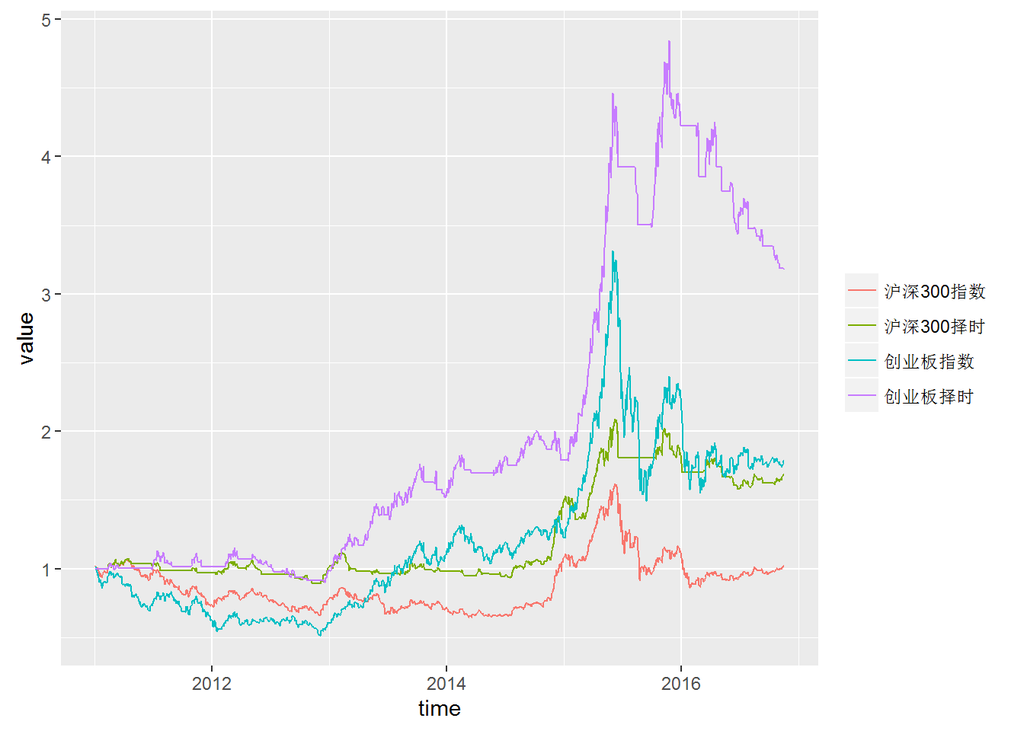

择时模型和指数的收益率统计如下表：

|  | 沪深300指 | 沪深300LLT | 创业板指 | 创业板MA |
| --- | --- | --- | --- | --- |
| 2011-01-04 ~ 2011-12-30 | -25.9% | -2.9% | -37% | 1% |
| 2012-01-04 ~ 2012-12-31 | 6.1% | 4.8% | -3% | -2% |
| 2013-01-04 ~ 2013-12-31 | -8.7% | -3.7% | 81% | 54% |
| 2014-01-02 ~ 2014-12-31 | 49.8% | 51.3% | 11% | 17% |
| 2015-01-05 ~ 2015-12-31 | 4.3% | 23.4% | 82% | 136% |
| 2016-01-04 ~ 2016-11-16 | -9.1% | -7.9% | -20% | -25% |
| 累计收益率 | 2.0% | 68.5% | 79% | 218% |
| 年化收益率 | 0.3% | 9.3% | 10% | 22% |
| 年化波动率 | 24.8% | 15.8% | 34% | 23% |
| 年化Sharpe值 | 1.4% | 58.7% | 31% | 96% |
| 最大回撤 | 47.1% | 24.4% | 55% | 34% |

择时模型最近10个交易日的信号如下表：

| 日期 | 沪深300收盘价 | 沪深300LLT | 沪深300择时信号 | 创业板收盘价 | 创业板MA30 | 创业板择时信号 |
| --- | --- | --- | --- | --- | --- | --- |
| 2016-11-03 | 3365.085 | 3335.324 | hold | 2153.185 | 2172.695 |  |
| 2016-11-04 | 3354.175 | 3338.283 | hold | 2145.229 | 2172.718 |  |
| 2016-11-07 | 3356.592 | 3340.798 | hold | 2130.301 | 2171.554 |  |
| 2016-11-08 | 3371.118 | 3343.717 | hold | 2150.302 | 2171.283 |  |
| 2016-11-09 | 3353.055 | 3346.355 | hold | 2123.845 | 2170.007 |  |
| 2016-11-10 | 3390.612 | 3349.473 | hold | 2143.321 | 2169.170 |  |
| 2016-11-11 | 3417.221 | 3354.501 | hold | 2147.107 | 2168.857 |  |
| 2016-11-14 | 3430.248 | 3360.547 | hold | 2161.686 | 2170.149 |  |
| 2016-11-15 | 3429.870 | 3366.681 | hold | 2179.300 | 2171.433 | buy |
| 2016-11-16 | 3429.592 | 3372.467 | hold | 2182.467 | 2172.861 | hold |

### (三)网格交易

在经历了三轮股灾，A股逐步回归正常，在过去的一段时间呈现一个震荡的格局，如果未来没有增量信息，很可能维持震荡。结合股指期货的贴水，前期研究了一下网格交易。网格交易的结果如下图：

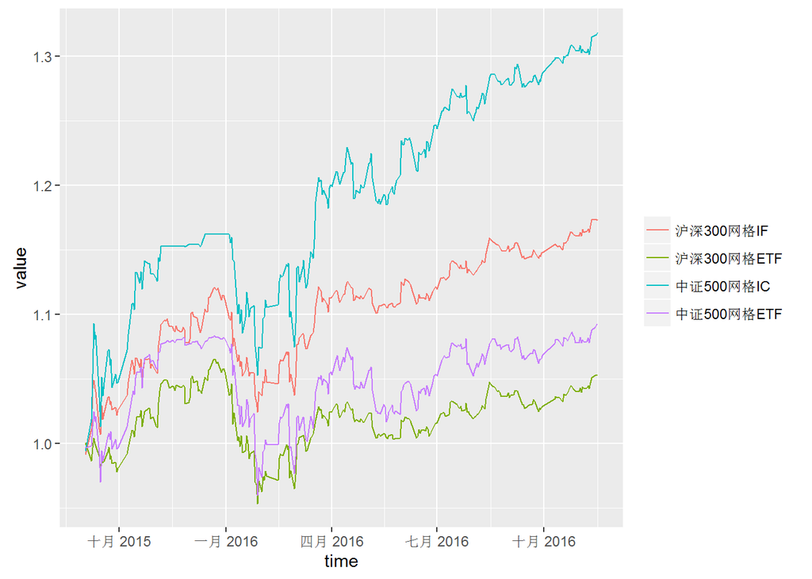

网格交易沪深300股指期货的最新仓位是34.1%，中证500股指期货的最新仓位是38.3%,网格交易的收益统计如下表：

|  | 沪深300指数 | 沪深300网格IF | 沪深300网格ETF | 中证500指数 | 中证500网格IC | 中证500网格ETF |
| --- | --- | --- | --- | --- | --- | --- |
| 2015-09-02 ~ 2015-12-31 | 11.0% | 11% | 5.6% | 23.5% | 16% | 8.1% |
| 2016-01-04 ~ 2016-11-16 | -8.1% | 6% | -0.3% | -12.8% | 13% | 1.1% |
| 累计收益率 | 2.0% | 17% | 5.3% | 7.7% | 32% | 9.2% |
| 年化收益率 | 1.7% | 14% | 4.3% | 6.3% | 26% | 7.6% |
| 年化波动率 | 24.4% | 10% | 9.9% | 32.9% | 15% | 12.7% |
| 年化Sharpe值 | 6.8% | 138% | 43.6% | 19.2% | 170% | 59.4% |
| 最大回撤 | 26.4% | 9% | 10.5% | 33.5% | 9% | 11.4% |

### (四)银行股轮动

银行股轮动是参考集思录的热门贴银行股评级而来的，数据的提取和参数的设置和原贴有一定的差别，所以轮动的效果也会不太一样，不过回测的效果还不错，从现在开始跟踪。2013年以来银行股轮动的结果如下图：

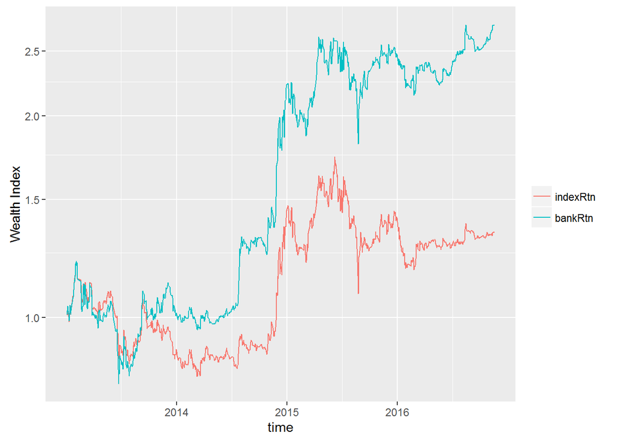

银行股轮动的收益统计如下表：

|  | 申万银行 | 银行股轮动 |
| --- | --- | --- |
| 2013-01-04 ~ 2013-12-31 | -10.3% | 2% |
| 2014-01-02 ~ 2014-12-31 | 61.3% | 119% |
| 2015-01-05 ~ 2015-12-31 | -2.6% | 11% |
| 2016-01-04 ~ 2016-11-16 | -4.9% | 11% |
| 累计收益率 | 34.0% | 174% |
| 年化收益率 | 7.9% | 30% |
| 年化波动率 | 29.3% | 32% |
| 年化Sharpe值 | 26.8% | 92% |
| 最大回撤 | 37.6% | 34% |

银行股轮动的最新得分如下表：

| 日期 | 代码 | 简称 | PB | 预期ROE | 翻倍期 | 持仓 |
| --- | --- | --- | --- | --- | --- | --- |
| 2016-11-16 | EQ601328 | 交通银行 | 0.69 | 0.11 | 2.98 |  |
| 2016-11-16 | EQ601988 | 中国银行 | 0.72 | 0.12 | 3.21 |  |
| 2016-11-16 | EQ601818 | 光大银行 | 0.73 | 0.12 | 3.29 |  |
| 2016-11-16 | EQ600015 | 华夏银行 | 0.79 | 0.15 | 3.30 | hold |
| 2016-11-16 | EQ601288 | 农业银行 | 0.78 | 0.13 | 3.61 |  |
| 2016-11-16 | EQ601398 | 工商银行 | 0.81 | 0.14 | 3.70 |  |
| 2016-11-16 | EQ000001 | 平安银行 | 0.80 | 0.13 | 3.90 |  |
| 2016-11-16 | EQ601939 | 建设银行 | 0.85 | 0.14 | 4.00 |  |
| 2016-11-16 | EQ601166 | 兴业银行 | 0.90 | 0.15 | 4.25 |  |
| 2016-11-16 | EQ600000 | 浦发银行 | 1.00 | 0.15 | 4.90 |  |
| 2016-11-16 | EQ601998 | 中信银行 | 0.91 | 0.12 | 5.32 |  |
| 2016-11-16 | EQ600016 | 民生银行 | 1.03 | 0.14 | 5.52 |  |
| 2016-11-16 | EQ601009 | 南京银行 | 1.05 | 0.14 | 5.58 |  |
| 2016-11-16 | EQ601169 | 北京银行 | 1.04 | 0.14 | 5.71 |  |
| 2016-11-16 | EQ600036 | 招商银行 | 1.15 | 0.15 | 5.96 |  |
| 2016-11-16 | EQ002142 | 宁波银行 | 1.33 | 0.15 | 6.96 |  |